# Tests für unabhängige Stichproben

2020-12-16

**Kernfragen dieser Lehreinheit**

- Wie fertige ich Deskriptivstatistiken (Grafiken, Kennwerte) zur Veranschaulichung des Unterschieds zwischen zwei Gruppen an?

**unabhängige Stichproben**

- Was sind Voraussetzungen des *t*-Tests und wie prüfe ich sie?
- Wie führe ich einen *t*-Test in R durch?
- Wie berechne ich die Effektstärke Cohen’s *d*?
- Wie führe ich den Wilcoxon-Tests (auch “Mann-Whitney-Test”, “U-Test” “Mann-Whitney-U-Test”, “Wilcoxon-Rangsummentest”) in R durch?
- Wie führe ich den Vierfelder-Chi-Quadrat-Tests in R durch?
- Wie berichte ich die statistischen Ergebnisse formal?

## Was erwartet Sie?

Nachdem wir uns die letzten Wochen mit dem Unterschied zwischen dem Mittelwert einer Stichprobe und dem Mittelwert der dazugehörigen Population, aus der die Stichprobe stammt, auseinandergesetzt haben, fokussieren wir uns nun auf Unterschiede zwischen zwei Gruppen (also zwei Stichproben).

## Aufbau der Sitzung

**unabhängige Stichproben**

1. Fragestellung A: Unterscheidet sich die Anzahl erreichter Punkte in der Statistik-Klausur zwischen Personen, die das Tutorium regelmäßig besucht haben und denen, die nur unregelmäßig da waren? (*t-Test, Cohen’s d*)
2. Fragestellung B: Sind Studentinnen verträglicher als Studenten? (*Wilcoxon-Test*)
3. Fragestellung C: Haben Studierende mit Wohnort in Uninähe (Frankfurt) mit gleicher Wahrscheinlichkeit einen Nebenjob wie Studierende, deren Wohnort außerhalb von Frankfurt liegt? (*Vierfelder-$\chi^2$-Test*)

## 1. Fragestellung A: Unterscheidet sich die Anzahl erreichter Punkte in der Statistik-Klausur zwischen Personen, die das Tutorium regelmäßig besucht haben und denen, die nur unregelmäßig da waren?

### Vorbereitung: Datenerzeugung

Mithilfe unseres fb20-Datensatzes lässt sich diese Frage leider nicht beantworten. Wir nutzen daher die Funktion `rnorm()` und simulieren unsere Daten selbst, d.h. wir erstellen einen neuen Datensatz mit fiktiven Werten.

Dabei nehmen wir für unsere beiden Gruppen (regelmäßige Teilnahme: ja bzw. nein) folgendes an:

- Stichprobengröße: 65 bzw. 53
- Mittelwert der Punktzahl: 37.2 bzw. 33.8
- Standardabweichung der Punktzahl: 5.4 bzw. 6.2

```r
set.seed(123)

# Datensatz für die Gruppe der regelmäßigen Teilnehmer
gruppe.regel <- data.frame(Gruppe = "ja",
                           Punktzahl = round(rnorm(n = 65, mean = 37.2, sd = 5.4)))

# Datensatz für die Gruppe der unregelmäßigen Teilnehmer
gruppe.unreg <- data.frame(Gruppe = "nein",
                           Punktzahl = round(rnorm(n = 53, mean = 33.8, sd = 6.2)) )

# Datensätze "untereinander" zusammenfügen mit rbind.data.frame()
dataA <- rbind.data.frame(gruppe.regel, gruppe.unreg)

# Prüfen, ob es geklappt hat
dim(dataA)
```

```
## [1] 118   2
```

```r
head(dataA)
```

```
##   Gruppe Punktzahl
## 1     ja        34
## 2     ja        36
## 3     ja        46
## 4     ja        38
## 5     ja        38
## 6     ja        46
```

```r
tail(dataA)
```

```
##     Gruppe Punktzahl
## 113   nein        24
## 114   nein        33
## 115   nein        37
## 116   nein        36
## 117   nein        34
## 118   nein        30
```

### 1.1. Deskriptivstatistik

#### 1.1.1. grafisch

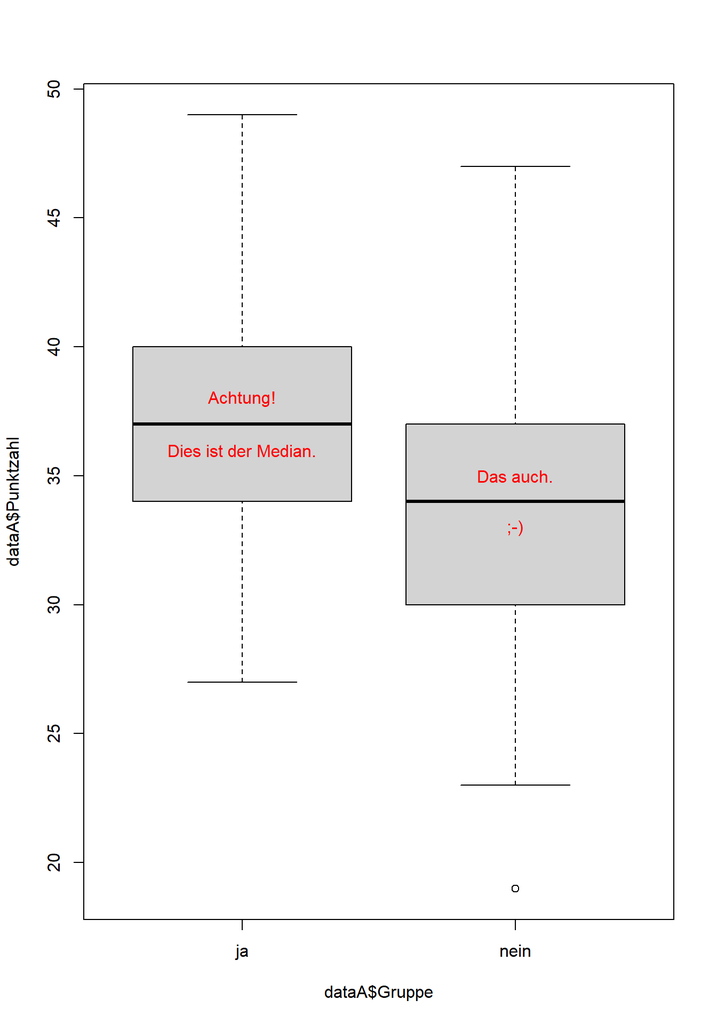

```r
# Gruppierter Boxplot:
boxplot(dataA$Punktzahl ~ dataA$Gruppe)
text("Achtung!", x=1, y=(median(dataA[(dataA$Gruppe=="ja"), "Punktzahl"]) + 1), col="red")
text("Dies ist der Median.", x=1, y=(median(dataA[(dataA$Gruppe=="ja"), "Punktzahl"]) - 1), col="red")
text("Das auch.", x=2, y=(median(dataA[(dataA$Gruppe=="nein"), "Punktzahl"]) + 1), col="red")
text(";-)", x=2, y=(median(dataA[(dataA$Gruppe=="nein"), "Punktzahl"]) - 1), col="red")
```

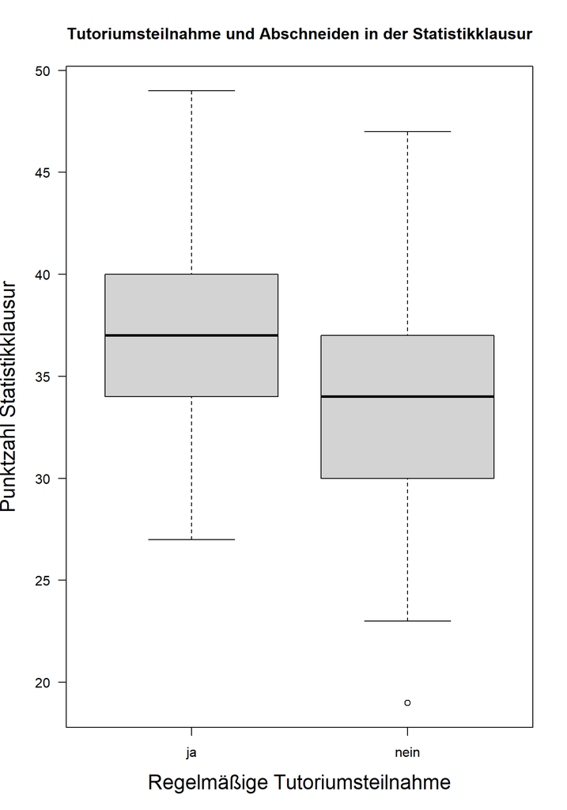

```r
# Gruppierter Boxplot (aussagekräftiger):
boxplot(dataA$Punktzahl ~ dataA$Gruppe,
        xlab="Regelmäßige Tutoriumsteilnahme", ylab="Punktzahl Statistikklausur",
        las=1, cex.lab=1.5,
        main="Tutoriumsteilnahme und Abschneiden in der Statistikklausur")
```

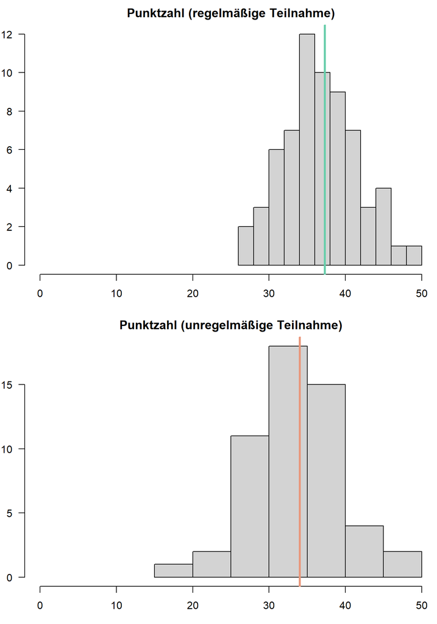

```r
# Je ein Histogramm pro Gruppe, untereinander dargestellt, vertikale Linie für den jeweiligen Mittelwert
par(mfrow=c(2,1), mar=c(3,2,2,0))
hist(dataA[(dataA$Gruppe=="ja"), "Punktzahl"], main="Punktzahl (regelmäßige Teilnahme)",
     xlim=c(0,50), xlab="", ylab="", las=1)
abline(v=mean(dataA[(dataA$Gruppe=="ja"), "Punktzahl"], na.rm=T), col="aquamarine3", lwd=3)
hist(dataA[(dataA$Gruppe=="nein"), "Punktzahl"], main="Punktzahl (unregelmäßige Teilnahme)",
     xlim=c(0,50), xlab="", ylab="", las=1)
abline(v=mean(dataA[(dataA$Gruppe=="nein"), "Punktzahl"], na.rm=T), col="darksalmon", lwd=3)
```

```r
dev.off()
```

#### 1.1.2. statistisch

```r
# umständlich:
summary(dataA$Punktzahl[(dataA$Gruppe=="ja")])   # Gruppe 1: regelmäßige Teilnahme
```

```
##    Min. 1st Qu.  Median    Mean 3rd Qu.    Max.
##   27.00   34.00   37.00   37.32   40.00   49.00
```

```r
summary(dataA$Punktzahl[(dataA$Gruppe=="nein")]) # Gruppe 2: unregelmäßige Teilnahme
```

```
##    Min. 1st Qu.  Median    Mean 3rd Qu.    Max.
##   19.00   30.00   34.00   34.04   37.00   47.00
```

```r
# komfortabler:
library(psych)
describeBy(dataA$Punktzahl, dataA$Gruppe)        # beide Gruppen im Vergleich
```

```
##
##  Descriptive statistics by group
## group: ja
##    vars  n  mean   sd median trimmed  mad min max range skew kurtosis   se
## X1    1 65 37.32 4.91     37   37.23 4.45  27  49    22 0.16    -0.52 0.61
## ------------------------------------------------------------
## group: nein
##    vars  n  mean  sd median trimmed  mad min max range  skew kurtosis   se
## X1    1 53 34.04 5.6     34   34.07 5.93  19  47    28 -0.02     0.18 0.77
```

Achtung, bei den hier berichteten `sd` handelt es sich nicht um die Stichprobenkennwerte, sondern um die Populationsschätzer. Daher:

```r
punkte.regel <- dataA$Punktzahl[(dataA$Gruppe=="ja")]
sigma.regel <- sd(punkte.regel)
n.regel <- length(punkte.regel[!is.na(punkte.regel)])
sd.regel <- sigma.regel * sqrt((n.regel-1) / n.regel)
sd.regel
```

```
## [1] 4.867815
```

```r
punkte.unreg <- dataA$Punktzahl[(dataA$Gruppe=="nein")]
sigma.unreg <- sd(punkte.unreg)
n.unreg <- length(punkte.unreg[!is.na(punkte.unreg)])
sd.unreg <- sigma.unreg * sqrt((n.unreg-1) / n.unreg)
sd.unreg
```

```
## [1] 5.545565
```

### 1.2. Voraussetzungsprüfung

**Voraussetzungen für die Durchführung des *t*-Tests**

1. die abhängige Variable ist intervallskaliert $\rightarrow$ ok
2. die einzelnen Messwerte sind voneinander unabhängig (Messwert einer Vpn hat keinen Einfluss auf den Messwert einer anderen) $\rightarrow$ ok
3. das untersuchte Merkmal ist in den Grundgesamtheiten der beiden Gruppen normalverteilt $\rightarrow$ (ggf.) optische Prüfung
4. Homoskedastizität: Varianzen der Variablen innerhalb der Populationen sind gleich $\rightarrow$ Levene-Test

**zu 3): Optische Prüfung auf Normalverteilung in den beiden Gruppen**

Falls das Merkmal in der Population normalverteilt ist und die Stichproben (so wie hier) groß genug sind, darf diese Voraussetzung generell als erfüllt betrachtet werden ($\rightarrow$ Zentraler Grenzwertsatz). Für kleinere Stichproben empfiehlt sich eine optische Prüfung auf Normalverteilung. Zur optischen Prüfung auf Normalverteilung gibt es mehrere Möglichkeiten, von denen zwei im Folgenden erläutert und dann jeweils durchgeführt werden.

- Möglichkeit 1: die bei Normalverteilung erwartete Dichtefunktion über das Histogramm legen und so die Übereinstimmung beurteilen
- Möglichkeit 2: QQ-Plot (quantile-quantile): es wird die beobachtete Position eines Messwerts gegen diejenige Position, die unter Gültigkeit der Normalverteilung zu erwarten wäre, abgetragen. Bei Normalverteilung liegen die Punkte (in etwa) auf einer Geraden.

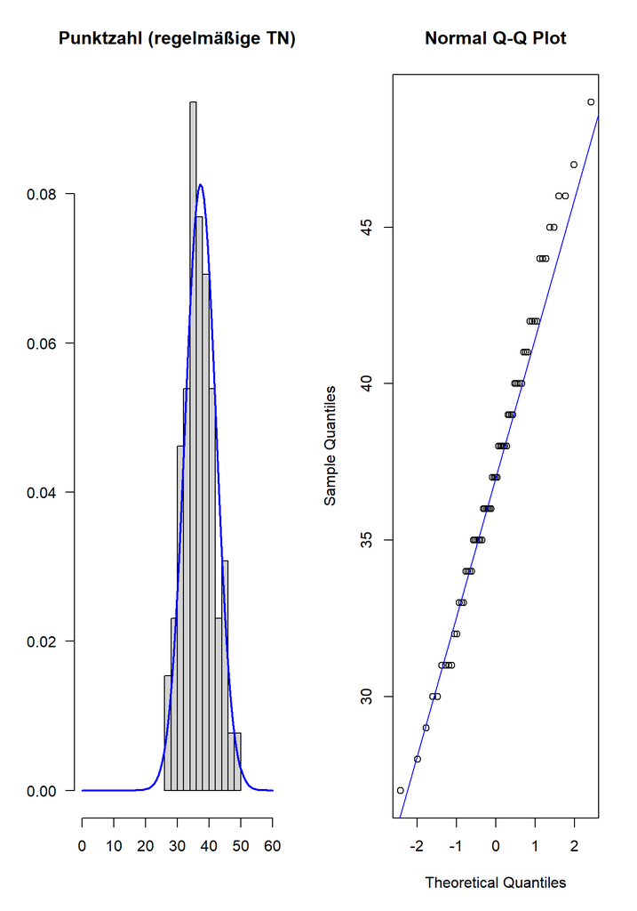

```r
# Gruppe 1 (regelmäßige Teilnahme)
par(mfrow=c(1,2))
punkte.regel <- dataA[(dataA$Gruppe=="ja"), "Punktzahl"]
hist(punkte.regel, xlim=c(0,60), main="Punktzahl (regelmäßige TN)", xlab="", ylab="", las=1, prob=T)
curve(dnorm(x, mean=mean(punkte.regel, na.rm=T), sd=sd(punkte.regel, na.rm=T)), col="blue", lwd=2, add=T)
qqnorm(punkte.regel)
qqline(punkte.regel, col="blue")
```

$\rightarrow$ Normalverteilung kann für Gruppe 1 (regelmäßige Teilnahme) angenommen werden

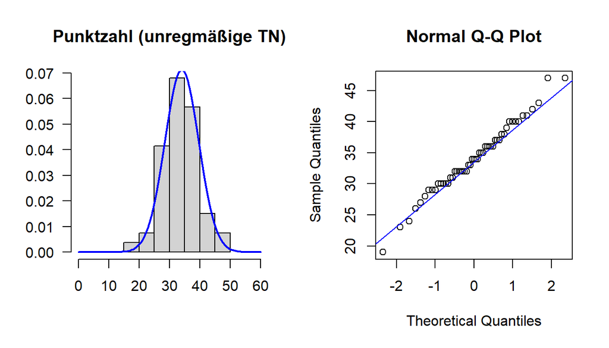

```r
# Gruppe 2 (unregelmäßige Teilnahme)
par(mfrow=c(1,2))
punkte.unreg <- dataA[(dataA$Gruppe=="nein"), "Punktzahl"]
hist(punkte.unreg, xlim=c(0,60), main="Punktzahl (unregmäßige TN)", xlab="", ylab="", las=1, prob=T)
curve(dnorm(x, mean=mean(punkte.unreg, na.rm=T), sd=sd(punkte.unreg, na.rm=T)), col="blue", lwd=2, add=T)
qqnorm(punkte.unreg)
qqline(punkte.unreg, col="blue")
```

$\rightarrow$ Normalverteilung kann auch für Gruppe 2 (unregelmäßige Teilnahme) angenommen werden

**zu 4) Test auf Homoskedastizität (Levene-Test)**

Das Hypothesenpaar im Levene-Test lautet:

- $H_0$: Homoskedastizität ist gegeben.
- $H_1$: Homoskedastizität ist nicht gegeben.

Ein nicht-signifikantes Ergebnis (*p* > .05) zeigt also Homoskedastizität an.

```r
library(car)
leveneTest(dataA$Punktzahl ~ dataA$Gruppe)
```

```
## Levene's Test for Homogeneity of Variance (center = median)
##        Df F value Pr(>F)
## group   1  0.4986 0.4815
##       116
```

*F*(1,116) = 0.499, *p* = .482 $\rightarrow$ Das Ergebnis ist nicht signifikant, die $H_0$ wird beibehalten. Homoskedastizität wird angenommen.

Für Fragestellung A sind somit alle Voraussetzungen für die Durchführung des *t*-Test erfüllt. :-) Hätte der Levene-Test keine Homoskedastizität angezeigt (*p* <. 05), so kann der *t*-Test trotzdem, nach Korrektur der Freiheitsgrade (“Welch-Korrektur”), durchgeführt werden (s.u.).

### 1.3. Inferenzstatistik: *t*-Test

Zur Erinnerung:

> Fragestellung A: “Unterscheidet sich die Anzahl erreichter Punkte in der Statistik-Klausur zwischen Personen, die das Tutorium regelmäßig besucht haben und denen, die nur unregelmäßig da waren?”

$\rightarrow$ Fragestellung ist ungerichtet, erfordert also auch ungerichtete Hypothesen.

**Hypothesen**

- Art des Effekts: Unterschiedshypothese
- Richtung des Effekts: Ungerichtet
- Größe des Effekts: Unspezifisch

Hypothesenpaar (inhaltlich):

- $H_0$: Studierende, die regelmäßig am Tutorium teilgenommen haben, unterscheiden sich nicht in der Punktzahl ihrer Statistikklausur von jenen, die nur unregelmäßig da waren.
- $H_1$: Studierende, die regelmäßig am Tutorium teilgenommen haben, unterscheiden sich in der Punktzahl ihrer Statistikklausur von jenen, die nur unregelmäßig da waren.

Hypothesenpaar (statistisch):

- $H_0$: $\mu_{regelmäßig} = \mu_{unregelmäßig}$ bzw. $\mu_{regelmäßig} - \mu_{unregelmäßig} = 0$
- $H_1$: $\mu_{regelmäßig} \ne \mu_{unregelmäßig}$ bzw. $\mu_{regelmäßig} - \mu_{unregelmäßig} \ne 0$

**Signifikanzniveau**

Das Signifikanzniveau muss vor der Untersuchung festgelegt werden. Es soll hier 5% betragen. $\rightarrow \alpha=.05$

**Durchführung des *t*-Tests in R: Funktion `t.test()`**

```r
t.test(dataA$Punktzahl ~ dataA$Gruppe,  # abhängige Variable ~ unabhängige Variable
      paired = FALSE,                   # Stichproben sind unabhängig
      alternative = "two.sided",        # zweiseitige Testung (Default)
      var.equal = TRUE,                 # Homoskedastizität liegt vor (-> Levene-Test)
      conf.level = .95)                 # alpha = .05 (Default)
```

```
##
##  Two Sample t-test
##
## data:  dataA$Punktzahl by dataA$Gruppe
## t = 3.3957, df = 116, p-value = 0.0009381
## alternative hypothesis: true difference in means between group ja and group nein is not equal to 0
## 95 percent confidence interval:
##  1.369061 5.201622
## sample estimates:
##   mean in group ja mean in group nein
##           37.32308           34.03774
```

*t*(*df* = 116, zweis.) = 3.396, *p* < .001 $\rightarrow$ signifikant, $H_0$ wird verworfen, $H_1$ wird angenommen.

### 1.4. Berechnung der Effektstärke Cohen’s *d*

$$d = \frac{\bar{x}_1-\bar{x}_2} {\hat{\sigma}_{inn}}$$
wobei

$${\hat{\sigma}_{inn}} = \sqrt{ \frac{{\hat{\sigma}_1^2}*(n_1-1) + {\hat{\sigma}^2_2}*(n_2-1)} {(n_1-1) + (n_2-1)} }$$
Cohen (1988) hat folgende Konventionen zur Beurteilung der Effektstärke *d* vorgeschlagen, die man heranziehen kann, um den Effekt “bei kompletter Ahnungslosigkeit” einschätzen zu können:

| *d* | Interpretation |
| --- | --- |
| ~ .2 | kleiner Effekt |
| ~ .5 | mittlerer Effekt |
| ~ .8 | großer Effekt |

**Berechnung von Hand**

```r
punkte.regel <- dataA[(dataA$Gruppe=="ja"), "Punktzahl"]
mw.regel <- mean(punkte.regel, na.rm=T)
n.regel <- length(punkte.regel[!is.na(punkte.regel)])
sigma.regel <- var(punkte.regel) * (n.regel - 1)

punkte.unreg <- dataA[(dataA$Gruppe=="nein"), "Punktzahl"]
mw.unreg <- mean(punkte.unreg, na.rm=T)
n.unreg <- length(punkte.unreg[!is.na(punkte.unreg)])
sigma.unreg <- var(punkte.unreg) * (n.unreg - 1)

sigma.inn <- sqrt((sigma.regel + sigma.unreg) / (n.regel-1 + n.unreg-1))

d1 <- (mw.regel - mw.unreg) / sigma.inn
d1
```

```
## [1] 0.6284493
```

**Berechnung mit Funktion `cohen.d()`**

```r
#alternativ:
#install.packages("effsize")
library("effsize")
```

```r
d2 <- cohen.d(dataA$Punktzahl, dataA$Gruppe)
d2
```

```
##
## Cohen's d
##
## d estimate: 0.6284493 (medium)
## 95 percent confidence interval:
##     lower     upper
## 0.2530381 1.0038605
```

Die Effektstärke für diesen Mittelwertsunterschied beträgt *d* = 0.628.

### 1.5. Ergebnisinterpretation

Zur Beantwortung der Fragestellung wurde ein *t*-Test unter Annahme von Homoskedastizität (*F*(1,116) = 0.499, *p* = .482) durchgeführt. Der Gruppenunterschied ist signifikant (*t*(*df* = 116, zweis.) = 3.396, *p* < .001), somit wird die Nullhypothese verworfen und die Alternativhypothese angenommen. Studierende, die regelmäßig am Tutorium teilgenommen haben, unterscheiden sich im Ergebnis der Statistikklausur (erreichte Punktzahl) bedeutsam von jenen, die nur unregelmäßig da waren.

## 2. Fragestellung B: Sind Studentinnen verträglicher als Studenten?

### 2.1 Vorbereitung (Daten einlesen, Daten aufbereiten)

```r
setwd("...")
load("fb20.rda")
```

```r
# Geschlecht als Faktor hinterlegen - aber nur dann, falls es noch keiner war
if(is.factor(fb20$geschl) == FALSE){           # falls Geschlecht noch nicht als Faktor vorliegt...
  fb20$geschl <- factor(fb20$geschl,           # ...wird ein Faktor erstellt
                        levels = c(1, 2, 3),
                        labels = c('weiblich', 'maennlich', 'anderes'))
  }
str(fb20)
```

```
## 'data.frame':    98 obs. of  32 variables:
##  $ mdbf1  : int  3 5 4 4 5 4 3 4 2 4 ...
##  $ mdbf2  : int  2 3 4 2 4 4 4 2 2 2 ...
##  $ mdbf3  : int  4 2 2 3 2 1 1 4 4 2 ...
##  $ mdbf4  : int  3 1 1 NA 1 1 2 3 4 2 ...
##  $ mdbf5  : int  2 3 1 4 1 1 1 3 4 4 ...
##  $ mdbf6  : int  1 4 4 2 4 3 4 3 2 4 ...
##  $ mdbf7  : int  2 3 1 5 2 3 1 4 4 4 ...
##  $ mdbf8  : int  3 5 4 3 5 4 4 4 2 4 ...
##  $ mdbf9  : int  4 1 2 4 2 1 1 4 4 2 ...
##  $ mdbf10 : int  3 3 4 1 3 4 3 3 2 4 ...
##  $ mdbf11 : int  2 1 1 3 2 1 1 3 5 2 ...
##  $ mdbf12 : int  2 5 4 2 4 4 4 2 2 4 ...
##  $ lz     : num  5.4 6.8 5 3.6 5.6 5.4 4.8 3.6 5 5.4 ...
##  $ extra  : num  3.5 4 3.5 2.75 4.25 3 3.5 4 3.25 3.5 ...
```

[output cut: 18 more lines]

Variable “geschl” liegt (nun) als Faktor vor.

### 2.2. Deskriptivstatistik

#### 2.2.1. grafisch

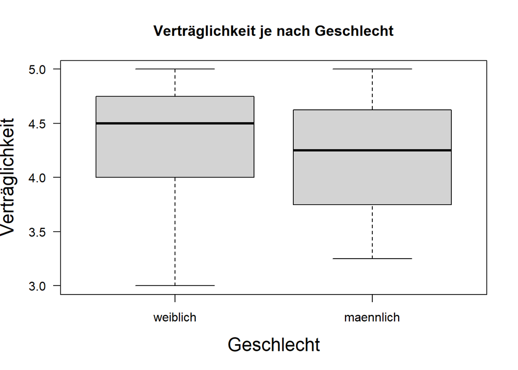

```r
# nur Männer und Frauen auswählen:
dataB <- fb20[ (fb20$geschl=="maennlich"|fb20$geschl=="weiblich"), ]
dataB$geschl <- droplevels(dataB$geschl)

# Gruppierter Boxplot:
boxplot(dataB$vertr ~ dataB$geschl,
        xlab="Geschlecht", ylab="Verträglichkeit",
        las=1, cex.lab=1.5,
        main="Verträglichkeit je nach Geschlecht")
```

Der Unterschied besteht in der erwarteten Richtung: höhere Verträglichkeit bei Studentinnen :-)

#### 2.2.2. statistisch

```r
describeBy(dataB$vertr, dataB$geschl) # beide Gruppen im Vergleich
```

```
##
##  Descriptive statistics by group
## group: weiblich
##    vars  n mean   sd median trimmed  mad min max range  skew kurtosis   se
## X1    1 73 4.32 0.53    4.5    4.35 0.74   3   5     2 -0.41    -0.92 0.06
## ------------------------------------------------------------
## group: maennlich
##    vars  n mean   sd median trimmed  mad  min max range  skew kurtosis   se
## X1    1 20 4.18 0.55   4.25    4.19 0.74 3.25   5  1.75 -0.17    -1.24 0.12
```

```r
# Interquartilsbereich (IBQ) über summary()
summary( dataB[(dataB$geschl=="weiblich"), "vertr"])
```

```
##    Min. 1st Qu.  Median    Mean 3rd Qu.    Max.    NA's
##   3.000   4.000   4.500   4.322   4.750   5.000       5
```

```r
summary( dataB[(dataB$geschl=="maennlich"), "vertr"])
```

```
##    Min. 1st Qu.  Median    Mean 3rd Qu.    Max.    NA's
##   3.250   3.750   4.250   4.175   4.562   5.000       5
```

### 2.3. Voraussetzungsprüfung

**Voraussetzungen für die Durchführung des *t*-Tests:**

1. die abhängige Variable ist intervallskaliert $\rightarrow$ ok
2. die einzelnen Messwerte sind voneinander unabhängig (Messwert einer Vpn hat keinen Einfluss auf den Messwert einer anderen) $\rightarrow$ ok
3. das untersuchte Merkmal ist in den Grundgesamtheiten der beiden Gruppen normalverteilt $\rightarrow$ (ggf.) optische Prüfung
4. Homoskedastizität: Varianzen der Variablen innerhalb der Populationen sind gleich $\rightarrow$ Levene-Test

**zu 3): Optische Prüfung auf Normalverteilung in den beiden Gruppen**

(Hinweis: In diesem Datenbeispiel betragen die Stichprobengrößen 73 (Gruppe “weiblich”) bzw. 20 (Gruppe “männlich”). Unter der Annahme von Normalverteilung des Merkmals “Verträglichkeit” in der Population könnte man bei diesen Stichprobengrößen von Normalverteilung ausgehen, ohne dies explizit zu prüfen, und einen *t*-Test durchführen (s.o.). Aus didaktischen Gründen betrachten wir hier die Normalverteilungsannahme als verletzt und führen daher den Wilcoxon-Test durch.)

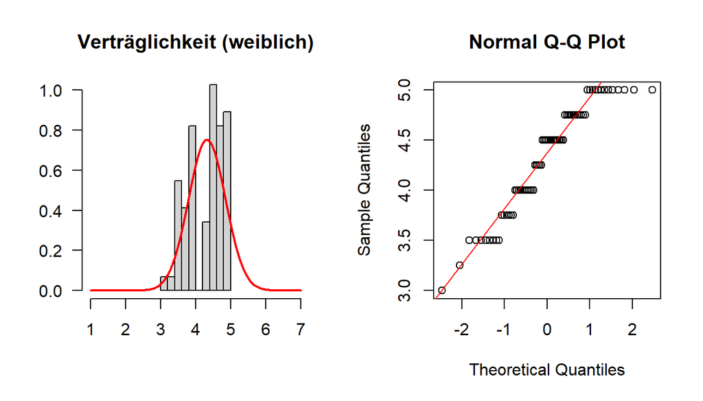

```r
#Gruppe 1 (weiblich)
par(mfrow=c(1,2))
vertr.w <- dataB[(dataB$geschl=="weiblich"), "vertr"]
hist(vertr.w, xlim=c(1,7), ylim=c(0,1), main="Verträglichkeit (weiblich)", xlab="", ylab="", las=1, prob=T)
curve(dnorm(x, mean=mean(vertr.w, na.rm=T), sd=sd(vertr.w, na.rm=T)), col="red", lwd=2, add=T)
qqnorm(vertr.w)
qqline(vertr.w, col="red")
```

$\rightarrow$ Entscheidung: Normalverteilung in Gruppe 1 (weiblich) ist nicht gegeben $\rightarrow$ Wilcoxon-Test

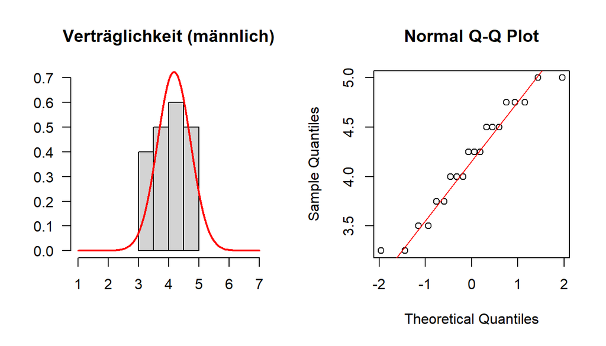

```r
#Gruppe 2 (männlich)
par(mfrow=c(1,2))
vertr.m <- dataB[(dataB$geschl=="maennlich"), "vertr"]
hist(vertr.m, xlim=c(1,7), ylim=c(0,.7), main="Verträglichkeit (männlich)", xlab="", ylab="", las=1, prob=T)
curve(dnorm(x, mean=mean(vertr.m, na.rm=T), sd=sd(vertr.m, na.rm=T)), col="red", lwd=2, add=T)
qqnorm(vertr.m)
qqline(vertr.m, col="red")
```

$\rightarrow$ Entscheidung: Normalverteilung in Gruppe 2 (männlich) ist auch nicht gegeben $\rightarrow$ Wilcoxon-Test

**zu 4) Test auf Homoskedastizität (Levene-Test)**

Das Hypothesenpaar im Levene-Test lautet:

- $H_0$: Homoskedastizität ist gegeben.
- $H_1$: Homoskedastizität ist nicht gegeben.

Ein nicht-signifikantes Ergebnis (*p* > .05) zeigt also Homoskedastizität an.

```r
library(car)
leveneTest(dataB$vertr ~ dataB$geschl)
```

```
## Levene's Test for Homogeneity of Variance (center = median)
##       Df F value Pr(>F)
## group  1  0.0188 0.8912
##       91
```

$F(1,91) = 0.019, p = .891 \rightarrow H_0$ wird beibehalten: Homoskedastizität wird angenommen

### 2.4. Inferenzstatistik: Wilcoxon-Test

Zur Erinnerung:

> Fragestellung B: “Sind Studentinnen *verträglicher* als Studenten?”

$\rightarrow$ Fragestellung ist gerichtet, erfordert also auch gerichtete Hypothesen.

**Hypothesen**

- Art des Effekts: Unterschiedshypothese
- Richtung des Effekts: Gerichtet
- Größe des Effekts: Unspezifisch

Hypothesenpaar (inhaltlich):

- $H_0$: Studentinnen sind weniger oder genauso verträglich wie Studenten.
- $H_1$: Studentinnen sind verträglicher als Studenten.

Hypothesenpaar (statistisch):

- $H_0$: $\eta_{weiblich} \leq \eta_{männlich}$ bzw. $\eta_{weiblich} - \eta_{männlich} \leq 0$
- $H_1$: $\eta_{weiblich} \gt \eta_{männlich}$ bzw. $\eta_{weiblich} - \eta_{männlich} \gt 0$

**Signifikanzniveau**

Das Signifikanzniveau muss vor der Untersuchung festgelegt werden. Es soll hier 5% betragen. $\rightarrow \alpha = .05$

**Durchführung des Wilcoxon-Tests in R: Funktion `wilcox.test()`**

```r
levels(dataB$geschl) # wichtig zu wissen: die erste der beiden Faktorstufen ist "weiblich"
```

```
## [1] "weiblich"  "maennlich"
```

```r
wilcox.test(dataB$vertr ~ dataB$geschl,   # abhängige Variable ~ unabhängige Variable
            paired = FALSE,               # Stichproben sind unabhängig
            alternative = "greater",      # einseitige Testung, und zwar so, dass Gruppe1(w)-Gruppe2(m) > 0
            conf.level = .95)             # alpha = .05
```

```
##
##  Wilcoxon rank sum test with continuity correction
##
## data:  dataB$vertr by dataB$geschl
## W = 845, p-value = 0.1394
## alternative hypothesis: true location shift is greater than 0
```

$W = 845, p = .139 \rightarrow$ Ergebnis ist nicht signfikant, $H_0$ wird beibehalten

### 2.5. Ergebnisinterpretation

Es wurde untersucht, ob Studentinnen verträglicher sind als Studenten. Tatsächlich besteht deskriptiv ein Unterschied in der erwarteten Richtung: Studentinnen weisen einen Median von 4.5 (*IQB* = [4.0; 4.75]), Studenten hingegen einen Wert von nur 4.25 (*IQB* = [3.75; 4.562]) auf. Zur Beantwortung der Fragestellung wurde ein Wilcoxon-Test durchgeführt. Demnach ist der Gruppenunterschied allerdings nicht signifikant (*W* = 845, *p* = .139). Somit wird die Nullhypothese beibehalten: Studentinnen sind nicht verträglicher als Studenten.

## 3. Fragestellung C: Haben Studierende mit Wohnort in Uninähe (Frankfurt) mit gleicher Wahrscheinlichkeit einen Nebenjob wie Studierende, deren Wohnort außerhalb von Frankfurt liegt?

Zusätzlich zur Gruppenvariable ist in diesem Beispiel auch die abhängige Variable nominalskaliert. Um Fragen wie diese zu beantworten, werden daher die Populationswahrscheinlichkeiten (job: ja vs. nein) zwischen den beiden Gruppen (ort: Frankfurt vs. außerhalb) miteinander verglichen. Diese Prüfung erfolgt mithilfe der $\chi^2$-Verteilung $\rightarrow \chi^2$-Test

### 3.1. Datenaufbereitung

```r
if(is.factor(fb20$ort) == FALSE){
  fb20$ort <- factor(fb20$ort, levels=c(1,2), labels=c("FFM", "anderer"))
}
if(is.factor(fb20$job) == FALSE){
  fb20$job <- factor(fb20$job, levels=c(1,2), labels=c("nein", "ja"))
}
```

### 3.2. Deskriptivstatistik/Voraussetzungsprüfung

**Voraussetzungen:**

1. Die einzelnen Beobachtungen sind voneinander unabhängig $\rightarrow$ ok
2. Jede Person lässt sich eindeutig einer Kategorie bzw. Merkmalskombination zuordnen $\rightarrow$ ok
3. Zellbesetzung für alle $n_{ij}$ > 5 $\rightarrow$ Prüfung anhand von Häufigkeitstabelle

**zu Punkt 3) Zellbesetzung *n* > 5**

```r
tab <- table(fb20$ort, fb20$job)
tab
```

```
##
##           nein ja
##   FFM       26 15
##   anderer   32 17
```

$\rightarrow n_{ij}$ > 5 in allen Zellen gegeben

### 3.3. Inferenzstatistische Beantwortung der Fragestellung

**Hypothesen**

- Art des Effekts: Zusammenhangshypothese
- Richtung des Effekts: Ungerichtet
- Größe des Effekts: Unspezifisch

Hyothesenpaar (inhaltlich):

- $H_0$: Studierende mit Wohnort in Uninähe haben mit gleicher Wahrscheinlichkeit einen Nebenjob wie Studierende, deren Wohnort außerhalb von Frankfurt liegt.
- $H_1$: Studierende mit Wohnort in Uninähe haben mit einer höheren oder niedrigeren Wahrscheinlichkeit einen Nebenjob wie Studierende, deren Wohnort außerhalb von Frankfurt liegt.

Hypothesenpaar (statistisch):

- $H_0$: $\pi_{ij} = \pi_{i\bullet} \cdot \pi_{\bullet j}$
- $H_1$: $\pi_{ij} \neq \pi_{i\bullet} \cdot \pi_{\bullet j}$

**Signifikanzniveau $\alpha$**

Die Irrtumswahrscheinlichkeit soll 5% betragen. $\rightarrow \alpha=.05$

#### 3.3.1. Vierfelder-$\chi^2$-Test in R: “manuelle” Berechnung über Formel

**erwartete Häufigkeiten berechnen**

Für jede Zelle lassen sich die unter Gültigkeit der Nullhypothese erwarteten Häufigkeiten $e_{ij}$ bestimmen:

$$e_{ij} = \frac{n_{i\bullet} \cdot n_{\bullet j}}{n}$$

```r
tab_mar <- addmargins(tab) # Randsummen zu Tabelle hinzufügen
tab_mar
```

```
##
##           nein ja Sum
##   FFM       26 15  41
##   anderer   32 17  49
##   Sum       58 32  90
```

```r
expected <- data.frame(nein=c((tab_mar[1,3]*tab_mar[3,1])/tab_mar[3,3],
                              (tab_mar[2,3]*tab_mar[3,1])/tab_mar[3,3]),
                       ja=c((tab_mar[1,3]*tab_mar[3,2])/tab_mar[3,3],
                            (tab_mar[2,3]*tab_mar[3,2])/tab_mar[3,3]))
expected
```

```
##       nein       ja
## 1 26.42222 14.57778
## 2 31.57778 17.42222
```

**Prüfgröße $\chi^2$ berechnen**

Formel:
$$\chi^2 = \sum_{i=1}^{2}{ \sum_{j=1}^{2}{ \frac{(n_{ij}-e_{ij})^2} {e_{ij}}}}$$

```r
chi_quadrat_Wert <- (tab[1,1]-expected[1,1])^2/expected[1,1]+
                    (tab[1,2]-expected[1,2])^2/expected[1,2]+
                    (tab[2,1]-expected[2,1])^2/expected[2,1]+
                    (tab[2,2]-expected[2,2])^2/expected[2,2]
chi_quadrat_Wert
```

```
## [1] 0.03485393
```

**Signfikanztestung: per Vergleich von empirischem und kritischem $\chi^2$**

Die Freiheitsgrade berechnen sich aus der Anzahl der untersuchten Kategorien: $df = (p - 1) \cdot (k - 1)$. Hier, im Fall des Vierfelder-$\chi^2$-Tests also mit $df = 1$, wobei

- *p*: Anzahl Kategorien Variable “ort” = 2
- *k*: Anzahl Kategorien Variable “job” = 2

Zur Bestimmung des kritischen Wertes und des $p$-Wertes:

```r
qchisq(.95, 1)
```

```
## [1] 3.841459
```

```r
pchisq(chi_quadrat_Wert, 1, lower.tail = FALSE)
```

```
## [1] 0.8519021
```

- *df* = 1
- $\chi^2_{krit}$ = 3.84
- $\chi^2_{emp}$ = 0.035
- $\chi^2_{emp} < \chi^2_{krit}$ $\rightarrow H_0$ wird beibehalten
- $p$ = 0.852
- $p$-Wert > $\alpha$-Fehlerniveau $\rightarrow H_0$ wird beibehalten

#### 3.3.2. Vierfelder-$\chi^2$-Test in R: Funktion `chisq.test()`

```r
chisq.test(tab,        # Kreuztabelle
           correct=F)  # keine Kontinuinitaetskorrektur nach Yates
```

```
##
##  Pearson's Chi-squared test
##
## data:  tab
## X-squared = 0.034854, df = 1, p-value = 0.8519
```

### 3.4. Effektstärken

**Yules Q**

```r
effekt_YulesQ <- (tab[1,1]*tab[2,2]-tab[1,2]*tab[2,1])/
                 (tab[1,1]*tab[2,2]+tab[1,2]*tab[2,1])
effekt_YulesQ
```

```
## [1] -0.04121475
```

Wertebereich zwischen -1 und 1; Interpretation analog zu Korrelationen

**Phi ($\phi$)**

```r
effekt_phi <- (tab[1,1]*tab[2,2]-tab[1,2]*tab[2,1])/
  sqrt((tab[1,1]+tab[1,2])*(tab[1,1]+tab[2,1])*(tab[1,2]+tab[2,2])*(tab[2,1]+tab[2,2]))
effekt_phi
```

```
## [1] -0.01967907
```

```r
# alternativ mit psych Paket
library(psych)
phi(tab, digits = 8)
```

```
## [1] -0.01967907
```

```r
# Äquivalentes Ergebnis mittels Pearson-Korrelation
# (dichotome Variablen)
ort_num <- as.numeric(fb20$ort)
job_num <- as.numeric(fb20$job)
cor(ort_num, job_num, use="pairwise")
```

```
## [1] -0.01967907
```

Wertebereich zwischen -1 und 1; Interpretation analog zu Korrelationen

### 3.5. Ergebnisinterpretation

Es wurde untersucht, ob Studierende mit Wohnort in Uninähe (also in Frankfurt) mit gleicher Wahrscheinlichkeit einen Nebenjob haben wie Studierende, deren Wohnort außerhalb von Frankfurt liegt. Zur Beantwortung der Fragestellung wurde ein Vierfelder-Chi-Quadrat-Test für unabhängige Stichproben berechnet. Der Zusammenhang zwischen Wohnort und Nebenjob ist nicht signifikant ($\chi^2$(1) = 0.035, *p* = 0.852), somit wird die Nullhypothese beibehalten. Der Effekt ist von vernachlässigbarer Stärke ($\phi$ = -0.02). Studierende mit Wohnort in Uninähe haben mit gleicher Wahrscheinlichkeit einen Nebenjob wie Studierende, deren Wohnort außerhalb von Frankfurt liegt.